# NikhilShankarCS_9026254_2_Lab_3

### **Lab-3**

#### **CSCN-8000 Artificial Intelligence Algorithm**

Prepared by

- Nikhil Shankar Chirakkal Sivasankaran
- 9026254
- Section 2

#### **1a. Identify Outliers using Whisker Approach**

|  | longitude | latitude | housing_median_age | total_rooms | total_bedrooms | population | households | median_income | median_house_value | ocean_proximity |
| --- | --- | --- | --- | --- | --- | --- | --- | --- | --- | --- |
| 0 | -122.74 | 39.71 | 16.0 | 255.0 | 73.0 | 85.0 | 38.0 | 1.6607 | 14999.0 | INLAND |
| 1 | -117.02 | 36.40 | 19.0 | 619.0 | 239.0 | 490.0 | 164.0 | 2.1000 | 14999.0 | INLAND |
| 2 | -117.86 | 34.24 | 52.0 | 803.0 | 267.0 | 628.0 | 225.0 | 4.1932 | 14999.0 | INLAND |
| 3 | -123.17 | 40.31 | 36.0 | 98.0 | 28.0 | 18.0 | 8.0 | 0.5360 | 14999.0 | INLAND |
| 4 | -118.33 | 34.15 | 39.0 | 493.0 | 168.0 | 259.0 | 138.0 | 2.3667 | 17500.0 | <1H OCEAN |
| ... | ... | ... | ... | ... | ... | ... | ... | ... | ... | ... |
| 20635 | -118.90 | 34.14 | 35.0 | 1503.0 | 263.0 | 576.0 | 216.0 | 5.1457 | 500001.0 | <1H OCEAN |
| 20636 | -118.69 | 34.18 | 11.0 | 1177.0 | 138.0 | 415.0 | 119.0 | 10.0472 | 500001.0 | <1H OCEAN |
| 20637 | -118.80 | 34.19 | 4.0 | 15572.0 | 2222.0 | 5495.0 | 2152.0 | 8.6499 | 500001.0 | <1H OCEAN |
| 20638 | -118.69 | 34.21 | 10.0 | 3663.0 | 409.0 | 1179.0 | 371.0 | 12.5420 | 500001.0 | <1H OCEAN |
| 20639 | -118.85 | 34.27 | 50.0 | 187.0 | 33.0 | 130.0 | 35.0 | 3.3438 | 500001.0 | <1H OCEAN |

20640 rows × 10 columns

|  | Lower Whisker | Upper Whisker | Count Lower Outliers | Count Upper Outliers | Highest Lower Outlier | Lowest Upper Outlier |
| --- | --- | --- | --- | --- | --- | --- |
| 0 | -96337.5 | 482162.5 | 0 | 1072 | None | 482200.0 |

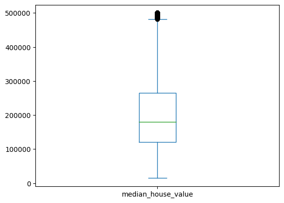

```python
from sklearn.datasets import load_diabetes
from sklearn.model_selection import train_test_split
from sklearn.linear_model import LinearRegression
from sklearn.metrics import mean_squared_error, mean_absolute_error
import pandas as pd
import numpy as np

df = pd.read_csv('data/housing_dataset.csv')
display(df)


#display whisker plot for median_house_value
median_house_value_column_name = 'median_house_value'
df[median_house_value_column_name].plot(kind='box', vert=True)

def calculateAndDisplayWHiskerStatistics(df, df_column_name):
    Q1 = df[df_column_name].quantile(0.25)
    Q3 = df[df_column_name].quantile(0.75)
    IQR = Q3 - Q1
    lower_whisker = Q1 - 1.5 * IQR
    upper_whisker = Q3 + 1.5 * IQR
    median = df[df_column_name].median()
    # Identify outliers
    lower_outliers = df[df[df_column_name] < lower_whisker]
    upper_outliers = df[df[df_column_name] > upper_whisker]
    count_of_lower_outliers = len(lower_outliers)
    count_of_upper_outliers = len(upper_outliers)
    highest_lower_outlier = "None"
    if not lower_outliers.empty:
        highest_lower_outlier = lower_outliers[df_column_name].max()
    lowest_upper_outlier = "None"
    if not upper_outliers.empty:
        lowest_upper_outlier = upper_outliers[df_column_name].min()
    data = np.array([[lower_whisker, upper_whisker, count_of_lower_outliers,
        count_of_upper_outliers, highest_lower_outlier, lowest_upper_outlier]])
    data_df = pd.DataFrame(data, columns=['Lower Whisker', 'Upper Whisker', 'Count Lower Outliers',
        'Count Upper Outliers', 'Highest Lower Outlier', 'Lowest Upper Outlier'])
    display(data_df)
    return

calculateAndDisplayWHiskerStatistics(df, median_house_value_column_name)
```

#### **1.b Z-Score normalization based Outlier Detection**

```python
from scipy.stats import zscore


print(df.dtypes)
print(f'Nan value Count : {df[median_house_value_column_name].isna().sum()}')

def calculateZScoreAndAppendToDF(df, column_name, zscore_column_name):
    # Note that we are omitting values which are nan for now. there are some rows with nan values we omit them while calculating zscore
    df[zscore_column_name] = zscore(df[column_name], nan_policy='omit')

def removeColumnFromDf(df, column_name_to_remove):
    # Drop the temporary z_score column
    df.drop(column_name_to_remove, axis=1, inplace=True)

def calculateAndDisplayOutliersBasedOnZscore(df, column_name, zscore_column_name, z_thresh=3.0):
    # Identify upper and lower outliers
    upper_outliers = df[df[zscore_column_name] > z_thresh][column_name]
    lower_outliers = df[df[zscore_column_name] < -z_thresh][column_name]
    # Calculate required values
    highest_lower_outlier = lower_outliers.max() if not lower_outliers.empty else np.nan
    lowest_upper_outlier = upper_outliers.min() if not upper_outliers.empty else np.nan
    count_upper_outliers = upper_outliers.count()
    count_lower_outliers = lower_outliers.count()
    result = np.array([[column_name, z_thresh, highest_lower_outlier, lowest_upper_outlier, count_lower_outliers, count_upper_outliers]])
    return result

def calculateZscoreOutliersInRange(df, column_name, zscore_column_name, range, stepsInSingleRange):
    result = np.empty((0,6))
    for i in range:
        result = np.vstack((result, calculateAndDisplayOutliersBasedOnZscore(df, column_name, zscore_column_name, i/stepsInSingleRange)))
    result_df = pd.DataFrame(result, columns=['Name', 'Z-Threshold', 'HighestLowerOutlier',
                                              'LowestHigherOutlier', 'CountLower', 'CountUpper'])
    display(result_df)

calculateZScoreAndAppendToDF(df, median_house_value_column_name, 'z-score')
calculateZscoreOutliersInRange(df, median_house_value_column_name, 'z-score', range(10,30), 10)
```

```
longitude             float64
latitude              float64
housing_median_age    float64
total_rooms           float64
total_bedrooms        float64
population            float64
households            float64
median_income         float64
median_house_value    float64
ocean_proximity        object
dtype: object
Nan value Count : 80
```

|  | Name | Z-Threshold | HighestLowerOutlier | LowestHigherOutlier | CountLower | CountUpper |
| --- | --- | --- | --- | --- | --- | --- |
| 0 | median_house_value | 1.0 | 91900.0 | 322700.0 | 2810 | 3333 |
| 1 | median_house_value | 1.1 | 80400.0 | 334300.0 | 1898 | 3035 |
| 2 | median_house_value | 1.2 | 68900.0 | 345800.0 | 1209 | 2739 |
| 3 | median_house_value | 1.3 | 57300.0 | 357300.0 | 507 | 2423 |
| 4 | median_house_value | 1.4 | 45800.0 | 368900.0 | 99 | 2190 |
| 5 | median_house_value | 1.5 | 34200.0 | 380400.0 | 23 | 2017 |
| 6 | median_house_value | 1.6 | 22500.0 | 391900.0 | 9 | 1874 |
| 7 | median_house_value | 1.7 | nan | 403700.0 | 0 | 1720 |
| 8 | median_house_value | 1.8 | nan | 415000.0 | 0 | 1597 |
| 9 | median_house_value | 1.9 | nan | 426500.0 | 0 | 1483 |
| 10 | median_house_value | 2.0 | nan | 438100.0 | 0 | 1380 |
| 11 | median_house_value | 2.1 | nan | 450000.0 | 0 | 1294 |
| 12 | median_house_value | 2.2 | nan | 461200.0 | 0 | 1178 |
| 13 | median_house_value | 2.3 | nan | 472700.0 | 0 | 1121 |
| 14 | median_house_value | 2.4 | nan | 484600.0 | 0 | 1057 |
| 15 | median_house_value | 2.5 | nan | 495800.0 | 0 | 1005 |
| 16 | median_house_value | 2.6 | nan | nan | 0 | 0 |
| 17 | median_house_value | 2.7 | nan | nan | 0 | 0 |
| 18 | median_house_value | 2.8 | nan | nan | 0 | 0 |
| 19 | median_house_value | 2.9 | nan | nan | 0 | 0 |

> We find that the zscore value when between 2.3 and 2.4 the count of outliers is between 1121 and 1057. For whisker approach we got upper value count as 1072 and lower count for both are 0.

> In order to find a more specific z-threshold we can run the function again this time step as 100.

```python
calculateZscoreOutliersInRange(df, median_house_value_column_name, 'z-score', range(230,240), 100)
```

|  | Name | Z-Threshold | HighestLowerOutlier | LowestHigherOutlier | CountLower | CountUpper |
| --- | --- | --- | --- | --- | --- | --- |
| 0 | median_house_value | 2.3 | nan | 472700.0 | 0 | 1121 |
| 1 | median_house_value | 2.31 | nan | 474000.0 | 0 | 1114 |
| 2 | median_house_value | 2.32 | nan | 475000.0 | 0 | 1107 |
| 3 | median_house_value | 2.33 | nan | 476300.0 | 0 | 1098 |
| 4 | median_house_value | 2.34 | nan | 477300.0 | 0 | 1091 |
| 5 | median_house_value | 2.35 | nan | 478500.0 | 0 | 1084 |
| 6 | median_house_value | 2.36 | nan | 479700.0 | 0 | 1080 |
| 7 | median_house_value | 2.37 | nan | 480800.0 | 0 | 1077 |
| 8 | median_house_value | 2.38 | nan | 482200.0 | 0 | 1072 |
| 9 | median_house_value | 2.39 | nan | 483100.0 | 0 | 1069 |

> So when **z-Threshold is 2.38** we get lower count and upper count of outliers exactly matching that of Whisker plot.

##### **Handling outliers**

```python
# finding top 5 most occuring value of median_house_value
most_frequent = df[median_house_value_column_name].value_counts().head(5)
print(f'Values with highest frequencies : \n{most_frequent}')

max_value_median_income = df[median_house_value_column_name].max()
print(f'Max Value for median house value {max_value_median_income}')
```

```
Values with highest frequencies :
median_house_value
500001.0    965
137500.0    122
162500.0    117
112500.0     93
187500.0     93
Name: count, dtype: int64
Max Value for median house value 500001.0
```

> Note that the frequency for the highest value of median_house_value is 500001 and its also the most frequently appearing one. This suggests the possibility of this value being a cap durng data collection. it satisfies NCAR and hence we decide to remove these rows from the dataset. It would not be correct to impute these rows with median or mode since there is a high chance that these values were above 500001 anyway.

```python
b_outlier_count = len(df)
print(f'Count before removing outliers {len(df)}')
df = df[df[median_house_value_column_name]< 500000]
print(f'Count after removing some outliers {len(df)}')
print(f'Ouliers removed {len(df) - b_outlier_count}')
```

```
Count before removing outliers 20640
Count after removing some outliers 19568
Ouliers removed -1072
```

```python
# Removing zscore column we created in dataframe
removeColumnFromDf(df, 'z-score')
```

#### **2. Handling Missing Values**

- Find data types of columns

```python
print(df.dtypes)
```

```
longitude             float64
latitude              float64
housing_median_age    float64
total_rooms           float64
total_bedrooms        float64
population            float64
households            float64
median_income         float64
median_house_value    float64
ocean_proximity        object
dtype: object
```

Except ocean_proximity all are numerical columns

```python
def displayEmptyNanRows(df):
    # Count NaN values in each column
    nan_counts = df.copy().isna().sum()
    # Count empty strings in each column
    empty_counts = (df == '').sum()
    # Combine results into a DataFrame for clearer display
    result = pd.DataFrame({
        'NaN Count': nan_counts,
        'Empty Count': empty_counts
    })
    display(result)
    return
displayEmptyNanRows(df)
```

|  | NaN Count | Empty Count |
| --- | --- | --- |
| longitude | 0 | 0 |
| latitude | 0 | 0 |
| housing_median_age | 3 | 0 |
| total_rooms | 11 | 0 |
| total_bedrooms | 200 | 0 |
| population | 10 | 0 |
| households | 14 | 0 |
| median_income | 4 | 0 |
| median_house_value | 0 | 0 |
| ocean_proximity | 147 | 0 |

##### **Plotting Histogram to analyse the features**

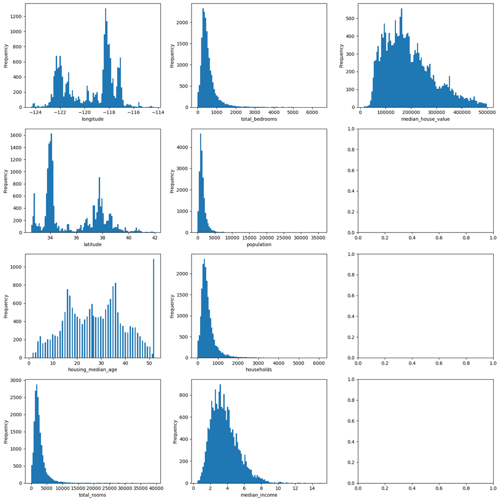

```python
import matplotlib.pyplot as plt

def plot_histogram(df):
    #Histogram is only for numerical values.
    numerical_df = df.select_dtypes(include=['number'])
    fig,axes = plt.subplots(4, int(len(numerical_df.columns)//4)+1, figsize=(15,15))
    for i, col_name in enumerate(numerical_df.columns):
        axes[i%4, i//4].hist(numerical_df[col_name], bins=100)
        axes[i%4, i//4].set_xlabel(col_name)
        axes[i%4, i//4].set_ylabel('Frequency')
    plt.tight_layout()
    plt.show()
    return

plot_histogram(df)
```

- Housing Median Age : From histogram we can see that its trimodal and not skewed. So we can use mean for imputing. We can also see that there is an abnormal frquency at the end like we saw in median_house_value. So we can check and see it it could be a case of capping.

```python
# finding top 5 most occuring value of median_house_value
most_frequent = df['housing_median_age'].value_counts().head(5)
print(f'Values with highest frequencies : \n{most_frequent}')

max_value_age = df['housing_median_age'].max()
print(f'Max Value for median age {max_value_age}')

#We confirm that there is an abnormal increase for age 52 and that also appears to be the max value. It could
# be because before that year ( current year - 52) there was no recordical data suggesting age of housing. Could
# be that age was started to be documented after that particular year in history. SO we remove it considering it NCAR.

b_outlier_count = len(df)
print(f'Count before removing outliers {len(df)}')
df = df[df['housing_median_age']< 52]
print(f'Count after removing some outliers {len(df)}')
print(f'Ouliers removed {len(df) - b_outlier_count}')
```

```
Values with highest frequencies :
housing_median_age
52.0    1086
36.0     822
35.0     786
16.0     753
17.0     684
Name: count, dtype: int64
Max Value for median age 52.0
Count before removing outliers 19568
Count after removing some outliers 18479
Ouliers removed -1089
```

```python
def impute(df_org, column_name, type):
    df_c = df_org.copy()
    if type == 'mean':
        mean = df_c[column_name].mean()
        print(f'Imputing with mean : {mean}')
        df_c[column_name] = df_c[column_name].fillna(mean)
        displayEmptyNanRows(df_c)
    elif type == 'mode':
        mode = df_c[column_name].mode()
        print(f'Imputing with mode : {mode}')
        df_c[column_name] = df_c[column_name].fillna(mode[0])
        displayEmptyNanRows(df_c)
    else:
        median = df_c[column_name].median()
        print(f'Imputing with median : {median}')
        df_c[column_name] = df_c[column_name].fillna(median)
        displayEmptyNanRows(df_c)
    return df_c

df = impute(df, 'housing_median_age', "mean")
```

```
Imputing with mean : 26.9589263488284
```

|  | NaN Count | Empty Count |
| --- | --- | --- |
| longitude | 0 | 0 |
| latitude | 0 | 0 |
| housing_median_age | 0 | 0 |
| total_rooms | 11 | 0 |
| total_bedrooms | 193 | 0 |
| population | 5 | 0 |
| households | 14 | 0 |
| median_income | 1 | 0 |
| median_house_value | 0 | 0 |
| ocean_proximity | 139 | 0 |

- total_rooms is right skewed. So we can use median to fill in the empty values.

```python
df = impute(df,'total_rooms', "median")
```

```
Imputing with median : 2144.0
```

|  | NaN Count | Empty Count |
| --- | --- | --- |
| longitude | 0 | 0 |
| latitude | 0 | 0 |
| housing_median_age | 0 | 0 |
| total_rooms | 0 | 0 |
| total_bedrooms | 193 | 0 |
| population | 5 | 0 |
| households | 14 | 0 |
| median_income | 1 | 0 |
| median_house_value | 0 | 0 |
| ocean_proximity | 139 | 0 |

- total_bedrooms : Is also right skewed and normally distributed so we choose median to impute

```python
df = impute(df, 'total_bedrooms', "median")
```

```
Imputing with median : 442.0
```

|  | NaN Count | Empty Count |
| --- | --- | --- |
| longitude | 0 | 0 |
| latitude | 0 | 0 |
| housing_median_age | 0 | 0 |
| total_rooms | 0 | 0 |
| total_bedrooms | 0 | 0 |
| population | 5 | 0 |
| households | 14 | 0 |
| median_income | 1 | 0 |
| median_house_value | 0 | 0 |
| ocean_proximity | 139 | 0 |

```python
df = impute(df, 'population', "median")
```

```
Imputing with median : 1205.0
```

|  | NaN Count | Empty Count |
| --- | --- | --- |
| longitude | 0 | 0 |
| latitude | 0 | 0 |
| housing_median_age | 0 | 0 |
| total_rooms | 0 | 0 |
| total_bedrooms | 0 | 0 |
| population | 0 | 0 |
| households | 14 | 0 |
| median_income | 1 | 0 |
| median_house_value | 0 | 0 |
| ocean_proximity | 139 | 0 |

- households: Again is right skewed and hence we select median to impute.

```python
df = impute(df, 'households', "median")
```

```
Imputing with median : 416.0
```

|  | NaN Count | Empty Count |
| --- | --- | --- |
| longitude | 0 | 0 |
| latitude | 0 | 0 |
| housing_median_age | 0 | 0 |
| total_rooms | 0 | 0 |
| total_bedrooms | 0 | 0 |
| population | 0 | 0 |
| households | 0 | 0 |
| median_income | 1 | 0 |
| median_house_value | 0 | 0 |
| ocean_proximity | 139 | 0 |

- median_income : is also slightly right skewed hence we choose median to impute

```python
df = impute(df, 'median_income', "median")
```

```
Imputing with median : 3.4773
```

|  | NaN Count | Empty Count |
| --- | --- | --- |
| longitude | 0 | 0 |
| latitude | 0 | 0 |
| housing_median_age | 0 | 0 |
| total_rooms | 0 | 0 |
| total_bedrooms | 0 | 0 |
| population | 0 | 0 |
| households | 0 | 0 |
| median_income | 0 | 0 |
| median_house_value | 0 | 0 |
| ocean_proximity | 139 | 0 |

- ocean_proximity: is a categorical value. It can be imputed with only mode.

```python
df = impute(df, 'ocean_proximity', 'mode')
```

```
Imputing with mode : 0    <1H OCEAN
Name: ocean_proximity, dtype: object
```

|  | NaN Count | Empty Count |
| --- | --- | --- |
| longitude | 0 | 0 |
| latitude | 0 | 0 |
| housing_median_age | 0 | 0 |
| total_rooms | 0 | 0 |
| total_bedrooms | 0 | 0 |
| population | 0 | 0 |
| households | 0 | 0 |
| median_income | 0 | 0 |
| median_house_value | 0 | 0 |
| ocean_proximity | 0 | 0 |

#### **3. Errors/Inconsistencies**

- For this we once again plot histogram.
- We already found 2 issues with capping in **median_house_value** and **housing_median_age** and we have removed it from the dataset.

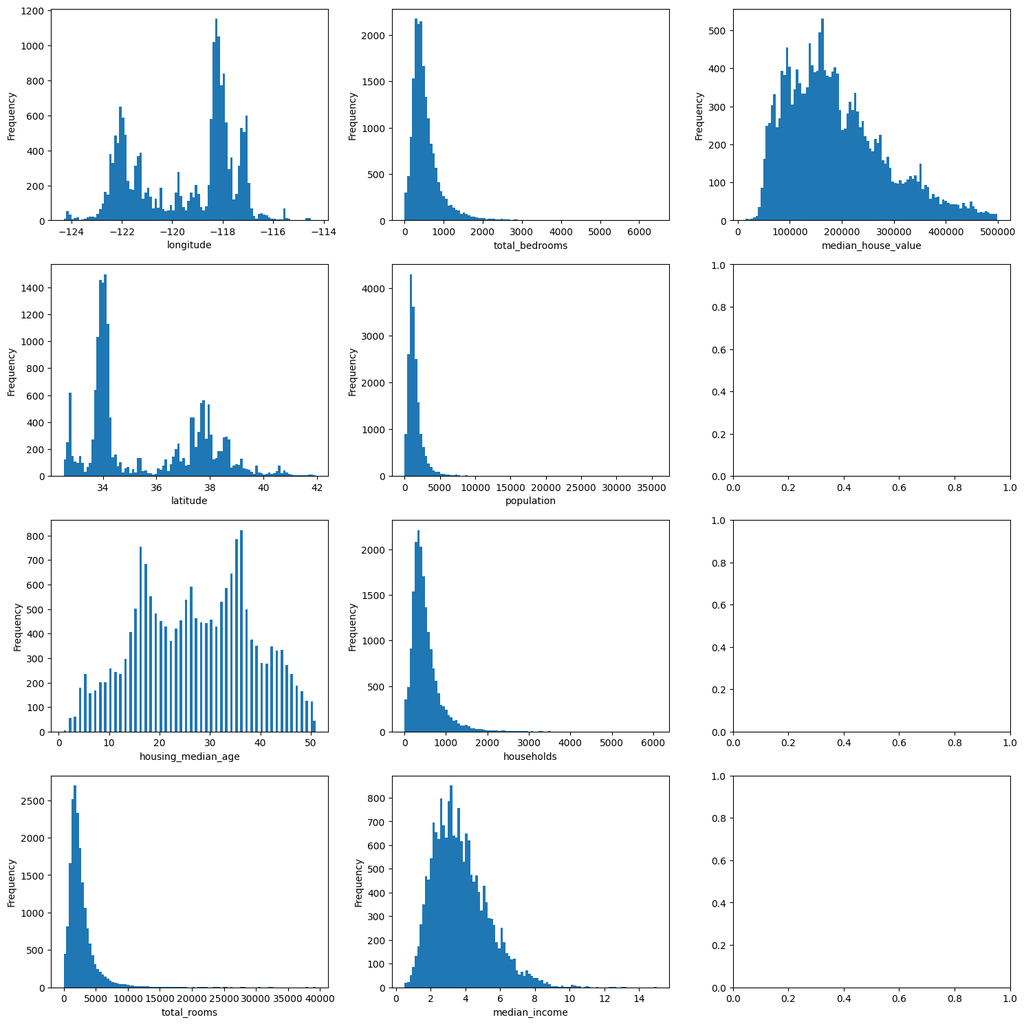

```python
plot_histogram(df)
```

- We can see that total_rooms, households, median_income, population, total_bedrooms and median_house_value are having close to zero value. We can investigate that further.

```python
min_values = df.select_dtypes(include='number').min()
print(min_values)
```

```
longitude              -124.3000
latitude                 32.5400
housing_median_age        1.0000
total_rooms               2.0000
total_bedrooms            2.0000
population                3.0000
households                2.0000
median_income             0.4999
median_house_value    14999.0000
dtype: float64
```

> All values are above zero. So nothing to do here.
- We can check for duplicated rows

```python
duplicates = df.duplicated().sum()
print(duplicates)
```

```
0
```

No Duplicate rows found

- Checking for unique values in categorical columns

```python
df['ocean_proximity'].unique()
```

```
array(['INLAND', '<1H OCEAN', 'NEAR BAY', 'NEAR OCEAN', 'inland',
       'NEAR_bay', 'ISLAND'], dtype=object)
```

- We can see that 'NEAR BAY' and 'NEAR_bay' are the same. 'INLAND' and 'inland' are also same.

We can correct this and make it uniform. And order it according to proximity to ocean.

- ISLAND
- NEAR OCEAN
- NEAR BAY - NEAR BAY and NEAR_bay
- MAX ONE HOUR DRIVE - <1H OCEAN
- INLAND

```python
df['ocean_proximity'] = df['ocean_proximity'].replace('NEAR_bay', 'NEAR BAY')
df['ocean_proximity'] = df['ocean_proximity'].replace('inland', 'INLAND')
df['ocean_proximity'] = df['ocean_proximity'].replace('<1H OCEAN', 'MAX ONE HOUR DRIVE')
df['ocean_proximity'].unique()


## Now lets order the categorical column as well.
ocean_proximity_order = ['ISLAND', 'NEAR OCEAN', 'NEAR BAY', 'MAX ONE HOUR DRIVE', 'INLAND']
df['ocean_proximity'] = pd.Categorical(df['ocean_proximity'], categories=ocean_proximity_order, ordered=True)
```

#### **4. Normalizing Features**

- We see that most of our features are normally distributed with some skewness.
- We also see couple of features that are bimodal but still normally distributed around the modes.
- We need to check the outliers that are present in other features before taking a decision whether to go with minMax, Z-Score or Robust normalization.

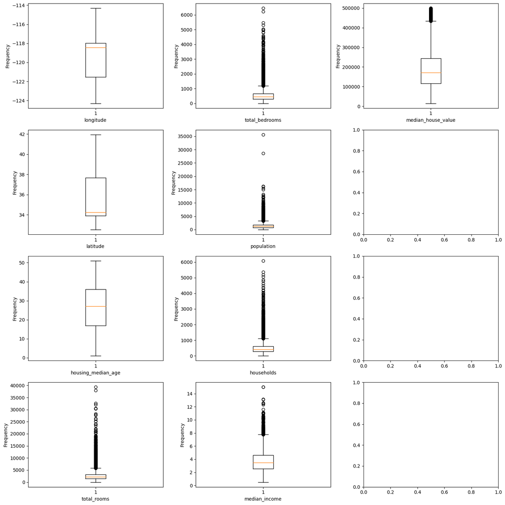

```python
def plot_whisker(df_org):
    df = df_org.select_dtypes(include=['number'])
    fig,axes = plt.subplots(4, int(len(df.columns)//4)+1, figsize=(15,15))
    for i, col_name in enumerate(df.columns):
        axes[i%4, i//4].boxplot(df[col_name])
        axes[i%4, i//4].set_xlabel(col_name)
        axes[i%4, i//4].set_ylabel('Frequency')
    plt.tight_layout()
    plt.show()
    return

plot_whisker(df)
```

> We can see that out of 9 numerical features 6 are having outliers. This points towards the fact that usage of Robust Scaling would be ideal.

> Since we are applying robust scaling for 6 columns we should stick to the same scaling for the other columns as well.

```python
def apply_robust_scaling(df):
    df_robust = df.copy()
    for i, column_name in enumerate(df_robust.select_dtypes(include=['number']).columns):
        median = df_robust[column_name].median()
        Q1 = df_robust[column_name].quantile(0.25)
        Q3 = df_robust[column_name].quantile(0.75)
        IQR = Q3-Q1
        print(f'median:{median} Q1:{Q1} Q3:{Q3} IQR:{IQR}')
        df_robust[column_name] = ((df_robust[column_name] - median)/IQR)
        df_robust = df_robust.rename(columns={column_name:f'{column_name}-rbst'})
    return df_robust

df_robust_scaled = apply_robust_scaling(df)

display(df_robust_scaled)
```

```
median:-118.45 Q1:-121.54 Q3:-117.97 IQR:3.5700000000000074
median:34.24 Q1:33.92 Q3:37.67 IQR:3.75
median:27.0 Q1:17.0 Q3:36.0 IQR:19.0
median:2144.0 Q1:1459.0 Q3:3187.0 IQR:1728.0
median:442.0 Q1:301.0 Q3:655.0 IQR:354.0
median:1205.0 Q1:812.0 Q3:1782.0 IQR:970.0
median:416.0 Q1:284.0 Q3:614.0 IQR:330.0
median:3.4773 Q1:2.5417 Q3:4.6238 IQR:2.0821
median:171400.0 Q1:116200.0 Q3:243400.0 IQR:127200.0
```

|  | longitude-rbst | latitude-rbst | housing_median_age-rbst | total_rooms-rbst | total_bedrooms-rbst | population-rbst | households-rbst | median_income-rbst | median_house_value-rbst | ocean_proximity |
| --- | --- | --- | --- | --- | --- | --- | --- | --- | --- | --- |
| 0 | -1.201681 | 1.458667 | -0.578947 | -1.093171 | -1.042373 | -1.154639 | -1.145455 | -0.872485 | -1.229568 | INLAND |
| 1 | 0.400560 | 0.576000 | -0.421053 | -0.882523 | -0.573446 | -0.737113 | -0.763636 | -0.661496 | -1.229568 | INLAND |
| 3 | -1.322129 | 1.618667 | 0.473684 | -1.184028 | -1.169492 | -1.223711 | -1.236364 | -1.412660 | -1.229568 | INLAND |
| 4 | 0.033613 | -0.024000 | 0.631579 | -0.955440 | -0.774011 | -0.975258 | -0.842424 | -0.533404 | -1.209906 | MAX ONE HOUR DRIVE |
| 5 | -1.084034 | 0.984000 | 0.315789 | -1.069444 | -1.042373 | -1.019588 | -1.069697 | -0.385332 | -1.170597 | NEAR BAY |
| ... | ... | ... | ... | ... | ... | ... | ... | ... | ... | ... |
| 19643 | 0.128852 | -0.077333 | 0.157895 | 0.042245 | -0.446328 | -0.364948 | -0.378788 | 3.364968 | 2.572327 | MAX ONE HOUR DRIVE |
| 19644 | 0.039216 | -0.029333 | 0.684211 | 0.392361 | 0.002825 | -0.307216 | -0.006061 | 1.821190 | 2.573113 | MAX ONE HOUR DRIVE |
| 19645 | -1.011204 | 0.824000 | 0.105263 | -0.115162 | -0.488701 | -0.390722 | -0.427273 | 2.291292 | 2.573899 | MAX ONE HOUR DRIVE |
| 19646 | -1.044818 | 0.973333 | -0.473684 | 1.563079 | 0.827684 | 0.442268 | 0.963636 | 2.243696 | 2.575472 | NEAR BAY |
| 19647 | 0.190476 | -0.184000 | 0.052632 | -0.069444 | -0.409605 | -0.606186 | -0.430303 | 1.589165 | 2.576258 | MAX ONE HOUR DRIVE |

18479 rows × 10 columns

#### **5. Encoding Categorical Columns**

- Ocean proximity unique values are 5. We saw it is based on the closeness to the ocean. Hence we can order the values numerically from closest to farthest.
- ISLAND - 4
- NEAR OCEAN - 3
- NEAR BAY - 2
- MAX ONE HOUR DRIVE - 1
- INLAND - 0

```python
from sklearn.preprocessing import OrdinalEncoder

#we have already defined the order previously. It would be better if we assign highest value ie 4 to ISLAND
# and lowest value 0 to INLAND.
encoder = OrdinalEncoder(categories=[ocean_proximity_order[::-1]])
df_robust_scaled['ocean_proximity'] = encoder.fit_transform(df_robust_scaled[['ocean_proximity']])
display(df_robust_scaled)
display(df_robust_scaled['ocean_proximity'].unique())
```

|  | longitude-rbst | latitude-rbst | housing_median_age-rbst | total_rooms-rbst | total_bedrooms-rbst | population-rbst | households-rbst | median_income-rbst | median_house_value-rbst | ocean_proximity |
| --- | --- | --- | --- | --- | --- | --- | --- | --- | --- | --- |
| 0 | -1.201681 | 1.458667 | -0.578947 | -1.093171 | -1.042373 | -1.154639 | -1.145455 | -0.872485 | -1.229568 | 0.0 |
| 1 | 0.400560 | 0.576000 | -0.421053 | -0.882523 | -0.573446 | -0.737113 | -0.763636 | -0.661496 | -1.229568 | 0.0 |
| 3 | -1.322129 | 1.618667 | 0.473684 | -1.184028 | -1.169492 | -1.223711 | -1.236364 | -1.412660 | -1.229568 | 0.0 |
| 4 | 0.033613 | -0.024000 | 0.631579 | -0.955440 | -0.774011 | -0.975258 | -0.842424 | -0.533404 | -1.209906 | 1.0 |
| 5 | -1.084034 | 0.984000 | 0.315789 | -1.069444 | -1.042373 | -1.019588 | -1.069697 | -0.385332 | -1.170597 | 2.0 |
| ... | ... | ... | ... | ... | ... | ... | ... | ... | ... | ... |
| 19643 | 0.128852 | -0.077333 | 0.157895 | 0.042245 | -0.446328 | -0.364948 | -0.378788 | 3.364968 | 2.572327 | 1.0 |
| 19644 | 0.039216 | -0.029333 | 0.684211 | 0.392361 | 0.002825 | -0.307216 | -0.006061 | 1.821190 | 2.573113 | 1.0 |
| 19645 | -1.011204 | 0.824000 | 0.105263 | -0.115162 | -0.488701 | -0.390722 | -0.427273 | 2.291292 | 2.573899 | 1.0 |
| 19646 | -1.044818 | 0.973333 | -0.473684 | 1.563079 | 0.827684 | 0.442268 | 0.963636 | 2.243696 | 2.575472 | 2.0 |
| 19647 | 0.190476 | -0.184000 | 0.052632 | -0.069444 | -0.409605 | -0.606186 | -0.430303 | 1.589165 | 2.576258 | 1.0 |

18479 rows × 10 columns

```
array([0., 1., 2., 3., 4.])
```

#### **6. Feature Engineering**

```python
print(df_robust_scaled['longitude-rbst'].nunique())
print(df_robust_scaled['latitude-rbst'].nunique())

combination_counts = df_robust_scaled.groupby(['latitude-rbst', 'longitude-rbst']).size().reset_index(name='count')

print(combination_counts)
```

```
834
857
       latitude-rbst  longitude-rbst  count
0          -0.453333        0.394958      1
1          -0.450667        0.380952      1
2          -0.450667        0.389356      1
3          -0.450667        0.394958      1
4          -0.448000        0.372549      1
...              ...             ...    ...
11830       2.032000       -0.974790      1
11831       2.037333       -1.507003      1
11832       2.048000       -1.599440      1
11833       2.056000       -1.593838      1
11834       2.056000       -1.173669      1

[11835 rows x 3 columns]
```

> We were checking if there were some unique locations we can find based on lat and longitude. But 11835 unique combinations were found. So we leave it at that.
- We have population and households value. This means we know the total number of people in the housing and number of apartments/houses. With this information we can calculate the No. of people per household.
- Household Strength = (Total Population / No. of households)

```python
df['household_strength'] = (df['population']/df['households'])
display(df)
```

|  | longitude | latitude | housing_median_age | total_rooms | total_bedrooms | population | households | median_income | median_house_value | ocean_proximity | household_strength |
| --- | --- | --- | --- | --- | --- | --- | --- | --- | --- | --- | --- |
| 0 | -122.74 | 39.71 | 16.0 | 255.0 | 73.0 | 85.0 | 38.0 | 1.6607 | 14999.0 | INLAND | 2.236842 |
| 1 | -117.02 | 36.40 | 19.0 | 619.0 | 239.0 | 490.0 | 164.0 | 2.1000 | 14999.0 | INLAND | 2.987805 |
| 3 | -123.17 | 40.31 | 36.0 | 98.0 | 28.0 | 18.0 | 8.0 | 0.5360 | 14999.0 | INLAND | 2.250000 |
| 4 | -118.33 | 34.15 | 39.0 | 493.0 | 168.0 | 259.0 | 138.0 | 2.3667 | 17500.0 | MAX ONE HOUR DRIVE | 1.876812 |
| 5 | -122.32 | 37.93 | 33.0 | 296.0 | 73.0 | 216.0 | 63.0 | 2.6750 | 22500.0 | NEAR BAY | 3.428571 |
| ... | ... | ... | ... | ... | ... | ... | ... | ... | ... | ... | ... |
| 19643 | -117.99 | 33.95 | 30.0 | 2217.0 | 284.0 | 851.0 | 291.0 | 10.4835 | 498600.0 | MAX ONE HOUR DRIVE | 2.924399 |
| 19644 | -118.31 | 34.13 | 40.0 | 2822.0 | 443.0 | 907.0 | 414.0 | 7.2692 | 498700.0 | MAX ONE HOUR DRIVE | 2.190821 |
| 19645 | -122.06 | 37.33 | 29.0 | 1945.0 | 269.0 | 826.0 | 275.0 | 8.2480 | 498800.0 | MAX ONE HOUR DRIVE | 3.003636 |
| 19646 | -122.18 | 37.89 | 18.0 | 4845.0 | 735.0 | 1634.0 | 734.0 | 8.1489 | 499000.0 | NEAR BAY | 2.226158 |
| 19647 | -117.77 | 33.55 | 28.0 | 2024.0 | 297.0 | 617.0 | 274.0 | 6.7861 | 499100.0 | MAX ONE HOUR DRIVE | 2.251825 |

18479 rows × 11 columns

- We can also calculate Empty Bedrooms. This might be a good indicator for households occupied based on economic conditions. The economically sound population can have spare bedrooms in their apartments.
- Another possibility is housing with a lot of vacant apartments can take this value high.
- Empty Bedrooms = total bedrooms - population

```python
df['empty_bedrooms'] = df['total_bedrooms'] - df['population']
display(df)
```

|  | longitude | latitude | housing_median_age | total_rooms | total_bedrooms | population | households | median_income | median_house_value | ocean_proximity | household_strength | empty_bedrooms |
| --- | --- | --- | --- | --- | --- | --- | --- | --- | --- | --- | --- | --- |
| 0 | -122.74 | 39.71 | 16.0 | 255.0 | 73.0 | 85.0 | 38.0 | 1.6607 | 14999.0 | INLAND | 2.236842 | -12.0 |
| 1 | -117.02 | 36.40 | 19.0 | 619.0 | 239.0 | 490.0 | 164.0 | 2.1000 | 14999.0 | INLAND | 2.987805 | -251.0 |
| 3 | -123.17 | 40.31 | 36.0 | 98.0 | 28.0 | 18.0 | 8.0 | 0.5360 | 14999.0 | INLAND | 2.250000 | 10.0 |
| 4 | -118.33 | 34.15 | 39.0 | 493.0 | 168.0 | 259.0 | 138.0 | 2.3667 | 17500.0 | MAX ONE HOUR DRIVE | 1.876812 | -91.0 |
| 5 | -122.32 | 37.93 | 33.0 | 296.0 | 73.0 | 216.0 | 63.0 | 2.6750 | 22500.0 | NEAR BAY | 3.428571 | -143.0 |
| ... | ... | ... | ... | ... | ... | ... | ... | ... | ... | ... | ... | ... |
| 19643 | -117.99 | 33.95 | 30.0 | 2217.0 | 284.0 | 851.0 | 291.0 | 10.4835 | 498600.0 | MAX ONE HOUR DRIVE | 2.924399 | -567.0 |
| 19644 | -118.31 | 34.13 | 40.0 | 2822.0 | 443.0 | 907.0 | 414.0 | 7.2692 | 498700.0 | MAX ONE HOUR DRIVE | 2.190821 | -464.0 |
| 19645 | -122.06 | 37.33 | 29.0 | 1945.0 | 269.0 | 826.0 | 275.0 | 8.2480 | 498800.0 | MAX ONE HOUR DRIVE | 3.003636 | -557.0 |
| 19646 | -122.18 | 37.89 | 18.0 | 4845.0 | 735.0 | 1634.0 | 734.0 | 8.1489 | 499000.0 | NEAR BAY | 2.226158 | -899.0 |
| 19647 | -117.77 | 33.55 | 28.0 | 2024.0 | 297.0 | 617.0 | 274.0 | 6.7861 | 499100.0 | MAX ONE HOUR DRIVE | 2.251825 | -320.0 |

18479 rows × 12 columns

Lets try histograms again to see how the newly calculated values are distributed.

|  | longitude | latitude | housing_median_age | total_rooms | total_bedrooms | population | households | median_income | median_house_value | household_strength | empty_bedrooms |
| --- | --- | --- | --- | --- | --- | --- | --- | --- | --- | --- | --- |
| count | 18479.000000 | 18479.000000 | 18479.000000 | 18479.000000 | 18479.000000 | 18479.000000 | 18479.000000 | 18479.000000 | 18479.000000 | 18479.000000 | 18479.000000 |
| mean | -119.479084 | 35.588102 | 26.958926 | 2672.558526 | 547.185508 | 1472.062503 | 509.145517 | 3.699297 | 189756.317820 | 3.109648 | -924.876996 |
| std | 1.976392 | 2.143499 | 11.431551 | 2227.052458 | 427.798592 | 1164.519860 | 389.926131 | 1.569683 | 95313.047075 | 10.838668 | 816.188100 |
| min | -124.300000 | 32.540000 | 1.000000 | 2.000000 | 2.000000 | 3.000000 | 2.000000 | 0.499900 | 14999.000000 | 0.692308 | -30863.000000 |
| 25% | -121.540000 | 33.920000 | 17.000000 | 1459.000000 | 301.000000 | 812.000000 | 284.000000 | 2.541700 | 116200.000000 | 2.469733 | -1141.000000 |
| 50% | -118.450000 | 34.240000 | 27.000000 | 2144.000000 | 442.000000 | 1205.000000 | 416.000000 | 3.477300 | 171400.000000 | 2.855967 | -742.000000 |
| 75% | -117.970000 | 37.670000 | 36.000000 | 3187.000000 | 655.000000 | 1782.000000 | 614.000000 | 4.623800 | 243400.000000 | 3.320000 | -475.000000 |
| max | -114.310000 | 41.950000 | 51.000000 | 39320.000000 | 6445.000000 | 35682.000000 | 6082.000000 | 15.000100 | 499100.000000 | 1243.333333 | 1330.000000 |

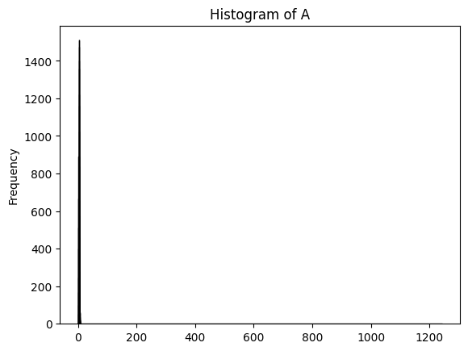

```python
df['household_strength'].plot(kind='hist', bins=10000, edgecolor='black', title='Histogram of A')
df.describe()
```

> The existence of a very high outlier is forcing this histogram to be displayed this way. If we perform outlier removal based on this new feature we will get a better histogram representation.

```python
display(df[df['empty_bedrooms']==-30863])
```

|  | longitude | latitude | housing_median_age | total_rooms | total_bedrooms | population | households | median_income | median_house_value | ocean_proximity | household_strength | empty_bedrooms |
| --- | --- | --- | --- | --- | --- | --- | --- | --- | --- | --- | --- | --- |
| 6224 | -117.42 | 33.35 | 14.0 | 25135.0 | 4819.0 | 35682.0 | 4769.0 | 2.5729 | 134400.0 | MAX ONE HOUR DRIVE | 7.482072 | -30863.0 |

> Realizing that it would be better to calculate Bedroom strength instead of empty bedrooms.

```python
df = df.drop('empty_bedrooms', axis=1)
```

bedroom_strength = total_bedrooms/population

```python
df['bedroom_strength'] = df['total_bedrooms'] / df['population']
display(df)
```

|  | longitude | latitude | housing_median_age | total_rooms | total_bedrooms | population | households | median_income | median_house_value | ocean_proximity | household_strength | bedroom_strength |
| --- | --- | --- | --- | --- | --- | --- | --- | --- | --- | --- | --- | --- |
| 0 | -122.74 | 39.71 | 16.0 | 255.0 | 73.0 | 85.0 | 38.0 | 1.6607 | 14999.0 | INLAND | 2.236842 | 0.858824 |
| 1 | -117.02 | 36.40 | 19.0 | 619.0 | 239.0 | 490.0 | 164.0 | 2.1000 | 14999.0 | INLAND | 2.987805 | 0.487755 |
| 3 | -123.17 | 40.31 | 36.0 | 98.0 | 28.0 | 18.0 | 8.0 | 0.5360 | 14999.0 | INLAND | 2.250000 | 1.555556 |
| 4 | -118.33 | 34.15 | 39.0 | 493.0 | 168.0 | 259.0 | 138.0 | 2.3667 | 17500.0 | MAX ONE HOUR DRIVE | 1.876812 | 0.648649 |
| 5 | -122.32 | 37.93 | 33.0 | 296.0 | 73.0 | 216.0 | 63.0 | 2.6750 | 22500.0 | NEAR BAY | 3.428571 | 0.337963 |
| ... | ... | ... | ... | ... | ... | ... | ... | ... | ... | ... | ... | ... |
| 19643 | -117.99 | 33.95 | 30.0 | 2217.0 | 284.0 | 851.0 | 291.0 | 10.4835 | 498600.0 | MAX ONE HOUR DRIVE | 2.924399 | 0.333725 |
| 19644 | -118.31 | 34.13 | 40.0 | 2822.0 | 443.0 | 907.0 | 414.0 | 7.2692 | 498700.0 | MAX ONE HOUR DRIVE | 2.190821 | 0.488423 |
| 19645 | -122.06 | 37.33 | 29.0 | 1945.0 | 269.0 | 826.0 | 275.0 | 8.2480 | 498800.0 | MAX ONE HOUR DRIVE | 3.003636 | 0.325666 |
| 19646 | -122.18 | 37.89 | 18.0 | 4845.0 | 735.0 | 1634.0 | 734.0 | 8.1489 | 499000.0 | NEAR BAY | 2.226158 | 0.449816 |
| 19647 | -117.77 | 33.55 | 28.0 | 2024.0 | 297.0 | 617.0 | 274.0 | 6.7861 | 499100.0 | MAX ONE HOUR DRIVE | 2.251825 | 0.481361 |

18479 rows × 12 columns

|  | longitude | latitude | housing_median_age | total_rooms | total_bedrooms | population | households | median_income | median_house_value | household_strength | bedroom_strength |
| --- | --- | --- | --- | --- | --- | --- | --- | --- | --- | --- | --- |
| count | 18479.000000 | 18479.000000 | 18479.000000 | 18479.000000 | 18479.000000 | 18479.000000 | 18479.000000 | 18479.000000 | 18479.000000 | 18479.000000 | 18479.000000 |
| mean | -119.479084 | 35.588102 | 26.958926 | 2672.558526 | 547.185508 | 1472.062503 | 509.145517 | 3.699297 | 189756.317820 | 3.109648 | 0.398721 |
| std | 1.976392 | 2.143499 | 11.431551 | 2227.052458 | 427.798592 | 1164.519860 | 389.926131 | 1.569683 | 95313.047075 | 10.838668 | 0.245626 |
| min | -124.300000 | 32.540000 | 1.000000 | 2.000000 | 2.000000 | 3.000000 | 2.000000 | 0.499900 | 14999.000000 | 0.692308 | 0.000670 |
| 25% | -121.540000 | 33.920000 | 17.000000 | 1459.000000 | 301.000000 | 812.000000 | 284.000000 | 2.541700 | 116200.000000 | 2.469733 | 0.311190 |
| 50% | -118.450000 | 34.240000 | 27.000000 | 2144.000000 | 442.000000 | 1205.000000 | 416.000000 | 3.477300 | 171400.000000 | 2.855967 | 0.366853 |
| 75% | -117.970000 | 37.670000 | 36.000000 | 3187.000000 | 655.000000 | 1782.000000 | 614.000000 | 4.623800 | 243400.000000 | 3.320000 | 0.436431 |
| max | -114.310000 | 41.950000 | 51.000000 | 39320.000000 | 6445.000000 | 35682.000000 | 6082.000000 | 15.000100 | 499100.000000 | 1243.333333 | 14.194444 |

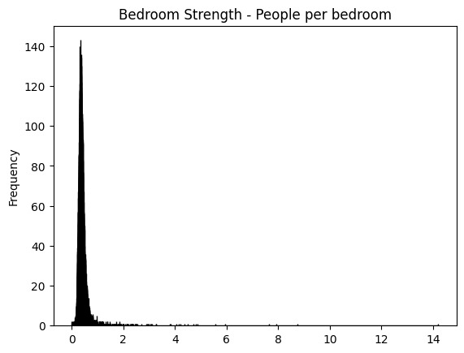

```python
df['bedroom_strength'].plot(kind='hist', bins=10000, edgecolor='black', title='Bedroom Strength - People per bedroom')
df.describe()
```

- Note here that the datapoints less than 1 is very high which means people sharing bedrooms are more than people who can afford to actually spare bedrooms.

#### **Descriptive analysis Tasks**

##### **Ocean Proximity and Housing Prices**

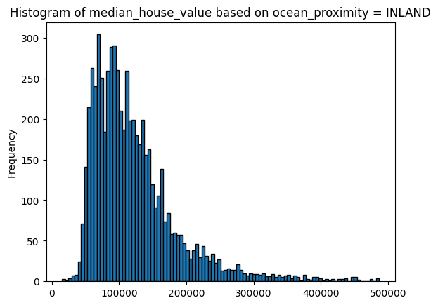

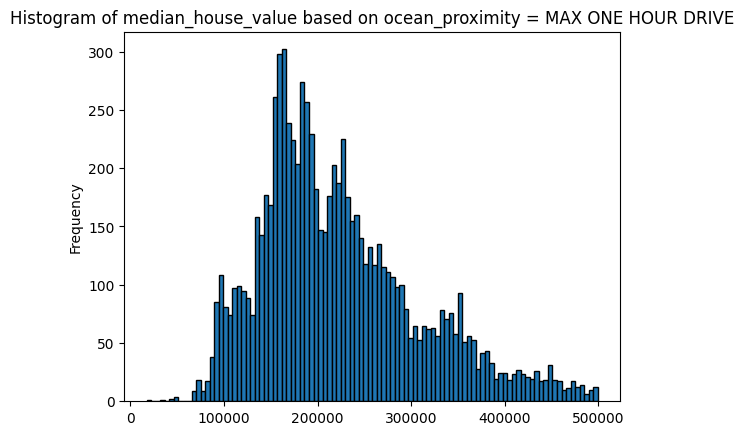

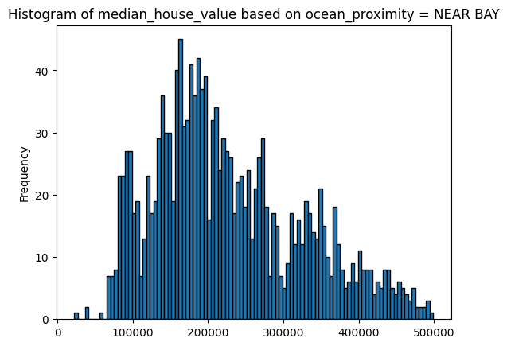

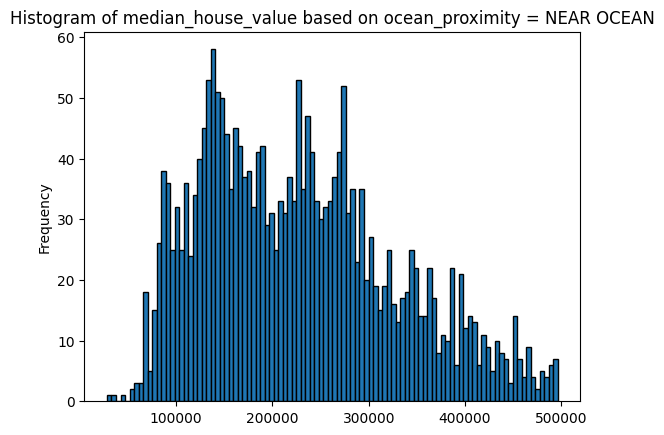

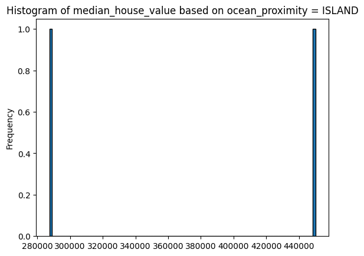

```
Summary
```

|  | Name | Mean | Min | Max | Count |
| --- | --- | --- | --- | --- | --- |
| 0 | INLAND | 122873.4218725163 | 14999.0 | 486800.0 | 6291 |
| 1 | MAX ONE HOUR DRIVE | 222825.89136156975 | 17500.0 | 499100.0 | 8358 |
| 2 | NEAR BAY | 226688.96866840732 | 22500.0 | 499000.0 | 1532 |
| 3 | NEAR OCEAN | 227833.84146341463 | 28300.0 | 496400.0 | 2296 |
| 4 | ISLAND | 368750.0 | 287500.0 | 450000.0 | 2 |

```python
def plot_histogram_based_on_category(df, category_column_name, target_column_name):
    result = np.empty((0,5))
    for value in df[category_column_name].unique():
        df_new = df[df[category_column_name] == value]
        df_new[target_column_name].plot(kind='hist', bins=100, edgecolor='black', title=f'Histogram of {target_column_name} based on {category_column_name} = {value}')
        plt.show()
        mean = df_new[target_column_name].mean()
        min = df_new[target_column_name].min()
        max = df_new[target_column_name].max()
        count = len(df_new[target_column_name])
        result = np.vstack((result, [[value, mean, min, max, count]]))
    result_df = pd.DataFrame(result, columns=['Name', 'Mean', 'Min', 'Max', 'Count'])
    print("Summary")
    display(result_df)
    return

plot_histogram_based_on_category(df, 'ocean_proximity', 'median_house_value')
```

- As ocean proximity increases we can see that the prices are going up.
- Most housings are located either inland or requires some driving to reach the ocean. This consitutes approximately more than 75% of housings.
- The maximum value of housing across all categories are close to each other. This could also be because there was a capping of housing values at 500001 and we have removed it.
- The number of housing in islands are very low or negligible when compared to the others.

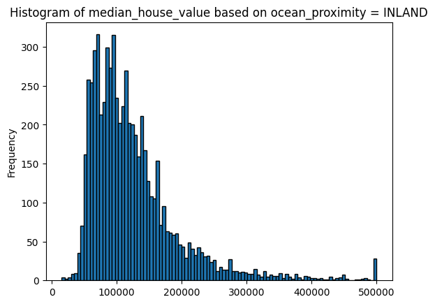

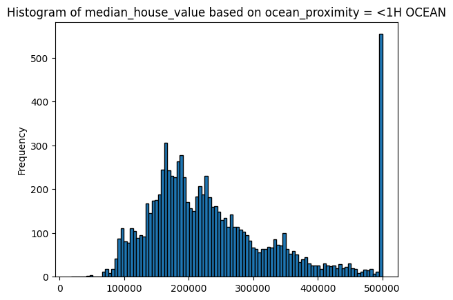

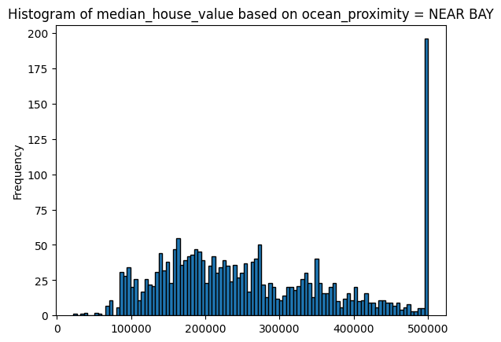

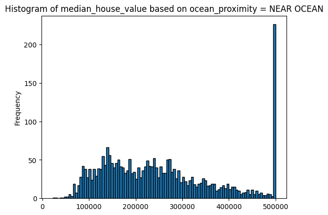

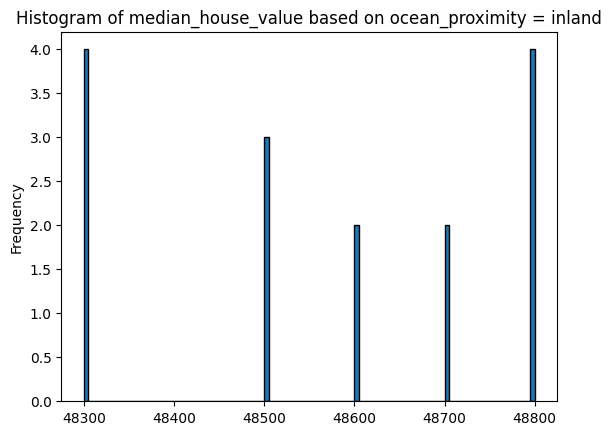

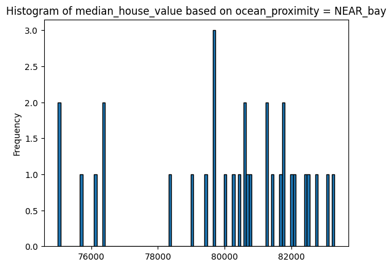

[figure not shown]

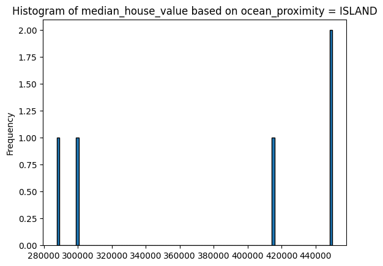

```
Summary
```

|  | Name | Mean | Min | Max | Count |
| --- | --- | --- | --- | --- | --- |
| 0 | INLAND | 124886.0375 | 14999.0 | 500001.0 | 6490 |
| 1 | <1H OCEAN | 241292.78396633817 | 17500.0 | 500001.0 | 9058 |
| 2 | NEAR BAY | 263464.53505201265 | 22500.0 | 500001.0 | 2239 |
| 3 | NEAR OCEAN | 250834.65501519758 | 22500.0 | 500001.0 | 2647 |
| 4 | inland | 48566.666666666664 | 48300.0 | 48800.0 | 15 |
| 5 | NEAR_bay | 80043.75 | 75000.0 | 83300.0 | 32 |
| 6 | nan | nan | nan | nan | 0.0 |
| 7 | ISLAND | 380440.0 | 287500.0 | 450000.0 | 5 |

```python
df_unfiltered = pd.read_csv('data/housing_dataset.csv')
plot_histogram_based_on_category(df_unfiltered, 'ocean_proximity', 'median_house_value')
```

- We just confirmed that the outliers we removed were not from one particular category. The distribution is across all different categories as is evident from the histogram.

#### **2. Relation between Income and Price**

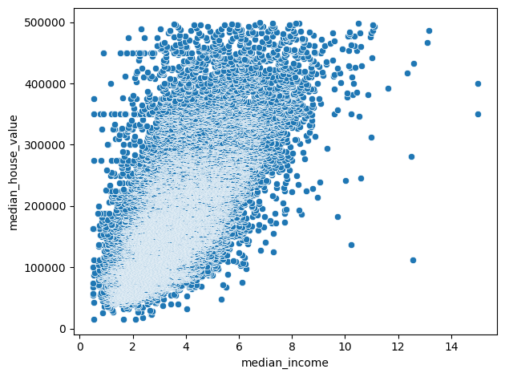

```python
import seaborn as sns


# created a function for plotting scatter diagram which uses seaborn.
def plot_scatter_diagram(df, column_name1, column_name2):
    sns.scatterplot(x=column_name1, y=column_name2, data=df)
    plt.tight_layout()
    plt.show()

plot_scatter_diagram(df, 'median_income', 'median_house_value')
```

- From the scatter plot we can realize that the median_income and median_house_value displays a linear upwards relation.
- This indicates that as the median_income goes up median_house_value is seen to go up as well.
- The inverse of that statement is also true. That is as median_income decreases we can see that the median_house_value also tends to decrease.
- It can also be observed that for outlier values of median_income the same cannot be said about median_house_values as it is seen to be scattered around 100000 and 500000 range. This could be because we removed the outliers.

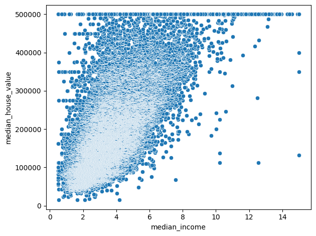

```python
plot_scatter_diagram(df_unfiltered, 'median_income', 'median_house_value')
```

- In the unfiltered dataset containing the extreme values we observe that it is spread across all incomes and not just high values of median_income. This could probably suggest an error in data collection wherein missing values were filled with a capped maximum value which we correctly removed.

### **ML Model Training and Testing Tasks**

We had created two new features but its not robust scaled and not part of the robust scaled dataset.

- Apply robust scaling to the two newly created columns and add it to the dataset.

```python
df_new_features= df[['household_strength','bedroom_strength']]
df_new_features_robust = apply_robust_scaling(df_new_features)
df_robust_scaled = df_robust_scaled.join(df_new_features_robust)
display(df_robust_scaled)
```

```
median:2.8559670781893005 Q1:2.469732988350254 Q3:3.32 IQR:0.8502670116497457
median:0.36685288640595903 Q1:0.31118961019875824 Q3:0.4364307000505548 IQR:0.12524108985179655
```

|  | longitude-rbst | latitude-rbst | housing_median_age-rbst | total_rooms-rbst | total_bedrooms-rbst | population-rbst | households-rbst | median_income-rbst | median_house_value-rbst | ocean_proximity | household_strength-rbst | bedroom_strength-rbst |
| --- | --- | --- | --- | --- | --- | --- | --- | --- | --- | --- | --- | --- |
| 0 | -1.201681 | 1.458667 | -0.578947 | -1.093171 | -1.042373 | -1.154639 | -1.145455 | -0.872485 | -1.229568 | 0.0 | -0.728154 | 3.928189 |
| 1 | 0.400560 | 0.576000 | -0.421053 | -0.882523 | -0.573446 | -0.737113 | -0.763636 | -0.661496 | -1.229568 | 0.0 | 0.155055 | 0.965356 |
| 3 | -1.322129 | 1.618667 | 0.473684 | -1.184028 | -1.169492 | -1.223711 | -1.236364 | -1.412660 | -1.229568 | 0.0 | -0.712679 | 9.491315 |
| 4 | 0.033613 | -0.024000 | 0.631579 | -0.955440 | -0.774011 | -0.975258 | -0.842424 | -0.533404 | -1.209906 | 1.0 | -1.151586 | 2.250026 |
| 5 | -1.084034 | 0.984000 | 0.315789 | -1.069444 | -1.042373 | -1.019588 | -1.069697 | -0.385332 | -1.170597 | 2.0 | 0.673441 | -0.230674 |
| ... | ... | ... | ... | ... | ... | ... | ... | ... | ... | ... | ... | ... |
| 19643 | 0.128852 | -0.077333 | 0.157895 | 0.042245 | -0.446328 | -0.364948 | -0.378788 | 3.364968 | 2.572327 | 1.0 | 0.080482 | -0.264513 |
| 19644 | 0.039216 | -0.029333 | 0.684211 | 0.392361 | 0.002825 | -0.307216 | -0.006061 | 1.821190 | 2.573113 | 1.0 | -0.782279 | 0.970692 |
| 19645 | -1.011204 | 0.824000 | 0.105263 | -0.115162 | -0.488701 | -0.390722 | -0.427273 | 2.291292 | 2.573899 | 1.0 | 0.173674 | -0.328862 |
| 19646 | -1.044818 | 0.973333 | -0.473684 | 1.563079 | 0.827684 | 0.442268 | 0.963636 | 2.243696 | 2.575472 | 2.0 | -0.740719 | 0.662430 |
| 19647 | 0.190476 | -0.184000 | 0.052632 | -0.069444 | -0.409605 | -0.606186 | -0.430303 | 1.589165 | 2.576258 | 1.0 | -0.710532 | 0.914305 |

18479 rows × 12 columns

#### **1. Train and Test Split**

```python
df_train = df_robust_scaled.sample(frac=0.8, random_state=50)
df_test = df_robust_scaled.drop(df_train.index)

print(f'Training Count : {len(df_train)} Testing Count : {len(df_test)}')
```

```
Training Count : 14783 Testing Count : 3696
```

#### **2. Closed Form Solution**

𝜃=(𝑋𝑇𝑋)−1𝑋𝑇𝑦

- y is the dependent column
- X is the independent column
- XT represents transpose of X
- raised to -1 means inverse

```python
def calculate_closed_form_coefficients(df, dependent_column_name, independent_column_name, title, shouldPrint=True):
    # converting panda series to numpy.
    X = df[[independent_column_name]].to_numpy()
    # we need a matrix with 1 filled in one column, this is required
    # so that bias can be added by multiplying with 1. And weight/slope will be
    # multiplied by the actual value.
    X = np.c_[np.full(X.shape[0], 1), X]
    y = df[dependent_column_name].to_numpy().reshape(-1,1)
    XT = X.T
    coefficients = np.dot(np.dot(np.linalg.inv(np.dot(XT,X)),XT),y)
    if shouldPrint:
        print(f'{title} dataset \n{coefficients} \nbias : {coefficients[0][0]} slope: {coefficients[1][0]}')
    return np.array([independent_column_name, coefficients[0][0], coefficients[1][0]])

_ = calculate_closed_form_coefficients(df_train, 'median_house_value-rbst', 'median_income-rbst', 'Training')
```

```
Training dataset
[[0.07716107]
 [0.65579253]]
bias : 0.0771610714794395 slope: 0.6557925305575832
```

```python
def calculate_all_coefficients(df, target_column_name):
    #removing categorical values if any
    num_df = df.select_dtypes(include='number')
    result = np.empty((0,3))
    for value in num_df.columns:
        coefficient_result = calculate_closed_form_coefficients(num_df, target_column_name, value, "", False)
        result = np.vstack((result, coefficient_result))
    result_df = pd.DataFrame(result, columns=['Name', 'Bias', 'Slope'])
    display(result_df)
    return result_df

coefficients_df = calculate_all_coefficients(df_train, 'median_house_value-rbst')
```

|  | Name | Bias | Slope |
| --- | --- | --- | --- |
| 0 | longitude-rbst | 0.13545389559860757 | -0.03152311219859857 |
| 1 | latitude-rbst | 0.2255906088810558 | -0.22552396642101477 |
| 2 | housing_median_age-rbst | 0.14458347701416907 | 0.026361453442510875 |
| 3 | total_rooms-rbst | 0.11779020157569639 | 0.08914858062727203 |
| 4 | total_bedrooms-rbst | 0.13045611058975215 | 0.04795856845892446 |
| 5 | population-rbst | 0.14144107118651764 | 0.011486122018146215 |
| 6 | households-rbst | 0.12705464441372405 | 0.06283612362355152 |
| 7 | median_income-rbst | 0.0771610714794395 | 0.6557925305575832 |
| 8 | median_house_value-rbst | -1.6818686200681388e-17 | 0.9999999999999993 |
| 9 | ocean_proximity | -0.15426367987503795 | 0.30216276790449476 |
| 10 | household_strength-rbst | 0.14567178509333298 | -0.006017501314385228 |
| 11 | bedroom_strength-rbst | 0.14092316013088005 | 0.013634977523034547 |

- The model is giving highest weight to **Median Income** which is around 0.65 and next is **Ocean Proximity** with a value of 0.3.

#### **4. Predictions**

```python
def predict_and_append(df, model_values_df):
    num_df = df.select_dtypes(include='number')
    for column_name in num_df.columns:
        X = df[[column_name]].to_numpy()
        X = np.c_[np.full(X.shape[0], 1), X]
        selected_row_of_model= model_values_df[model_values_df['Name'] == column_name]
        # we need to create a coefficient matrix.
        # the panda dataframe has casted it as a object
        # we need to extract it and convert it into float.
        # The syntax was very confusing and took me a lot of time to figure the issue.
        beta = np.array([[float(selected_row_of_model['Bias'].to_numpy()[0])],
                        [float(selected_row_of_model['Slope'].to_numpy()[0])]])
        predictions = np.dot(X,beta)
        df[f'{column_name}-pred'] = predictions
    return df

df_train_predicted = predict_and_append(df_train, coefficients_df)
df_test_predicted = predict_and_append(df_test, coefficients_df)
```

```python
display(df_train_predicted)
display(df_test_predicted)
```

|  | longitude-rbst | latitude-rbst | housing_median_age-rbst | total_rooms-rbst | total_bedrooms-rbst | population-rbst | households-rbst | median_income-rbst | median_house_value-rbst | ocean_proximity | ... | housing_median_age-rbst-pred | total_rooms-rbst-pred | total_bedrooms-rbst-pred | population-rbst-pred | households-rbst-pred | median_income-rbst-pred | median_house_value-rbst-pred | ocean_proximity-pred | household_strength-rbst-pred | bedroom_strength-rbst-pred |
| --- | --- | --- | --- | --- | --- | --- | --- | --- | --- | --- | --- | --- | --- | --- | --- | --- | --- | --- | --- | --- | --- |
| 8812 | 0.098039 | -0.074667 | 0.473684 | -0.555556 | -0.570621 | -0.267010 | -0.557576 | 0.268191 | -0.069969 | 1.0 | ... | 0.157070 | 0.068263 | 0.103090 | 0.138374 | 0.092019 | 0.253039 | -0.069969 | 0.147899 | 0.137026 | 0.128604 |
| 12753 | 0.120448 | -0.053333 | 0.000000 | 2.023148 | 1.579096 | 2.405155 | 1.703030 | 0.762547 | 0.345912 | 1.0 | ... | 0.144583 | 0.298151 | 0.206187 | 0.169067 | 0.234066 | 0.577234 | 0.345912 | 0.147899 | 0.140282 | 0.131786 |
| 17732 | 0.249300 | -0.109333 | 0.052632 | -0.722801 | -0.889831 | -0.885567 | -0.912121 | 0.961289 | 1.319969 | 0.0 | ... | 0.145971 | 0.053354 | 0.087781 | 0.131269 | 0.069740 | 0.707567 | 1.319969 | -0.154264 | 0.144591 | 0.140945 |
| 13839 | -0.938375 | 0.826667 | -0.105263 | -0.290509 | -0.409605 | -0.060825 | -0.415152 | 0.831612 | 0.471698 | 1.0 | ... | 0.141809 | 0.091892 | 0.110812 | 0.140742 | 0.100968 | 0.622526 | 0.471698 | 0.147899 | 0.136814 | 0.129199 |
| 13275 | -1.000000 | 0.885333 | -0.210526 | 1.266204 | 1.172316 | 1.294845 | 1.251515 | 0.423659 | 0.408805 | 2.0 | ... | 0.139034 | 0.230670 | 0.186679 | 0.156314 | 0.205695 | 0.354993 | 0.408805 | 0.450062 | 0.144874 | 0.138896 |
| ... | ... | ... | ... | ... | ... | ... | ... | ... | ... | ... | ... | ... | ... | ... | ... | ... | ... | ... | ... | ... | ... |
| 15449 | -0.980392 | 0.840000 | -0.157895 | 1.785880 | 1.389831 | 2.670103 | 1.678788 | 0.934393 | 0.728774 | 1.0 | ... | 0.140421 | 0.276999 | 0.197110 | 0.172110 | 0.232543 | 0.689929 | 0.728774 | 0.147899 | 0.138195 | 0.127778 |
| 4903 | 0.389356 | -0.058667 | -0.157895 | 1.023148 | 1.036723 | 0.743299 | 1.048485 | -0.379329 | -0.433176 | 0.0 | ... | 0.140421 | 0.209002 | 0.180176 | 0.149979 | 0.192937 | -0.171600 | -0.433176 | -0.154264 | 0.147996 | 0.146714 |
| 14959 | 0.179272 | -0.136000 | -0.421053 | 1.925347 | 2.550847 | 1.673196 | 2.518182 | 0.045435 | 0.639937 | 1.0 | ... | 0.133484 | 0.289432 | 0.252791 | 0.160660 | 0.285287 | 0.106957 | 0.639937 | 0.147899 | 0.149834 | 0.152763 |
| 10974 | 0.019608 | -0.077333 | 0.105263 | -0.186921 | 0.412429 | 0.197938 | 0.324242 | -0.429374 | 0.126572 | 1.0 | ... | 0.147358 | 0.101126 | 0.150236 | 0.143715 | 0.147429 | -0.204419 | 0.126572 | 0.147899 | 0.146980 | 0.146807 |
| 16168 | 0.039216 | -0.112000 | 0.421053 | 0.762731 | 1.050847 | 0.718557 | 0.860606 | -0.036165 | 0.852987 | 1.0 | ... | 0.155683 | 0.185787 | 0.180853 | 0.149695 | 0.181132 | 0.053444 | 0.852987 | 0.147899 | 0.146654 | 0.147577 |

14783 rows × 24 columns

|  | longitude-rbst | latitude-rbst | housing_median_age-rbst | total_rooms-rbst | total_bedrooms-rbst | population-rbst | households-rbst | median_income-rbst | median_house_value-rbst | ocean_proximity | ... | housing_median_age-rbst-pred | total_rooms-rbst-pred | total_bedrooms-rbst-pred | population-rbst-pred | households-rbst-pred | median_income-rbst-pred | median_house_value-rbst-pred | ocean_proximity-pred | household_strength-rbst-pred | bedroom_strength-rbst-pred |
| --- | --- | --- | --- | --- | --- | --- | --- | --- | --- | --- | --- | --- | --- | --- | --- | --- | --- | --- | --- | --- | --- |
| 1 | 0.400560 | 0.576000 | -0.421053 | -0.882523 | -0.573446 | -0.737113 | -0.763636 | -0.661496 | -1.229568 | 0.0 | ... | 0.133484 | 0.039115 | 0.102954 | 0.132974 | 0.079071 | -0.356643 | -1.229568 | -0.154264 | 0.144739 | 0.154086 |
| 12 | 1.058824 | -0.085333 | -0.526316 | -1.184606 | -1.180791 | -1.212371 | -1.215152 | -1.062245 | -1.131289 | 0.0 | ... | 0.130709 | 0.012184 | 0.073827 | 0.127516 | 0.050699 | -0.619451 | -1.131289 | -0.154264 | 0.152201 | 0.191083 |
| 19 | -0.859944 | 1.157333 | -0.157895 | -0.697917 | -0.471751 | -0.718557 | -0.493939 | -0.881466 | -1.091981 | 0.0 | ... | 0.140421 | 0.055572 | 0.107832 | 0.133188 | 0.096017 | -0.500898 | -1.091981 | -0.154264 | 0.151674 | 0.159919 |
| 35 | -0.425770 | 0.586667 | -0.473684 | -0.587963 | -0.579096 | -0.446392 | -0.593939 | -0.624466 | -1.039308 | 0.0 | ... | 0.132096 | 0.065374 | 0.102683 | 0.136314 | 0.089734 | -0.332359 | -1.039308 | -0.154264 | 0.141050 | 0.134406 |
| 38 | -0.375350 | 0.666667 | 0.421053 | -0.747106 | -0.412429 | 0.023711 | -0.384848 | -1.165170 | -1.036164 | 0.0 | ... | 0.155683 | 0.051187 | 0.110677 | 0.141713 | 0.102872 | -0.686949 | -1.036164 | -0.154264 | 0.135812 | 0.127226 |
| ... | ... | ... | ... | ... | ... | ... | ... | ... | ... | ... | ... | ... | ... | ... | ... | ... | ... | ... | ... | ... | ... |
| 19624 | 0.000000 | -0.058667 | 0.947368 | -0.528935 | -0.680791 | -0.659794 | -0.596970 | 1.380721 | 2.531447 | 1.0 | ... | 0.169557 | 0.070636 | 0.097806 | 0.133863 | 0.089543 | 0.982628 | 2.531447 | 0.147899 | 0.147626 | 0.139715 |
| 19631 | 0.016807 | -0.096000 | 0.315789 | 0.230903 | -0.008475 | -0.110309 | 0.000000 | 1.196388 | 2.547956 | 1.0 | ... | 0.152908 | 0.138375 | 0.130050 | 0.140174 | 0.127055 | 0.861744 | 2.547956 | 0.147899 | 0.147204 | 0.144512 |
| 19641 | 0.011204 | -0.026667 | 0.315789 | -0.790509 | -0.844633 | -0.976289 | -0.866667 | 1.085779 | 2.564465 | 1.0 | ... | 0.152908 | 0.047317 | 0.089949 | 0.130227 | 0.072597 | 0.789207 | 2.564465 | 0.147899 | 0.151839 | 0.161327 |
| 19644 | 0.039216 | -0.029333 | 0.684211 | 0.392361 | 0.002825 | -0.307216 | -0.006061 | 1.821190 | 2.573113 | 1.0 | ... | 0.162620 | 0.152769 | 0.130592 | 0.137912 | 0.126674 | 1.271484 | 2.573113 | 0.147899 | 0.150379 | 0.154159 |
| 19646 | -1.044818 | 0.973333 | -0.473684 | 1.563079 | 0.827684 | 0.442268 | 0.963636 | 2.243696 | 2.575472 | 2.0 | ... | 0.132096 | 0.257136 | 0.170151 | 0.146521 | 0.187606 | 1.548560 | 2.575472 | 0.450062 | 0.150129 | 0.149955 |

3696 rows × 24 columns

#### **5. MAE and MSE**

```python
print(df_test_predicted.shape)

def calculate_mae_mse(df, target_column_name, predicted_column_name):
    mae = np.mean(np.abs(df[target_column_name] - df[predicted_column_name]))
    mse = np.mean((df[target_column_name] - df[predicted_column_name]) ** 2)
    return np.array([predicted_column_name, mae, mse])

result = np.empty((0,3))
for i in range(12,24):
    result = np.vstack((result, calculate_mae_mse(df_test_predicted, 'median_house_value-rbst', df_test_predicted.columns[i])))
result_df = pd.DataFrame(result, columns=['Name', 'MAE', 'MSE'])
display(result_df)
```

```
(3696, 24)
```

|  | Name | MAE | MSE |
| --- | --- | --- | --- |
| 0 | longitude-rbst-pred | 0.5985862224575399 | 0.5612105485156451 |
| 1 | latitude-rbst-pred | 0.5902831533110995 | 0.5477123657933121 |
| 2 | housing_median_age-rbst-pred | 0.5995425727335466 | 0.5622385857115108 |
| 3 | total_rooms-rbst-pred | 0.590103998350451 | 0.5481073149284607 |
| 4 | total_bedrooms-rbst-pred | 0.5965471161288031 | 0.5578500623725758 |
| 5 | population-rbst-pred | 0.5991570173391588 | 0.5614188079545973 |
| 6 | households-rbst-pred | 0.5950060927723742 | 0.5558895513895357 |
| 7 | median_income-rbst-pred | 0.4245873119262775 | 0.3061837410713353 |
| 8 | median_house_value-rbst-pred | 3.902547071691599e-16 | 2.5871038888164666e-31 |
| 9 | ocean_proximity-pred | 0.5390234122762654 | 0.4780344754985553 |
| 10 | household_strength-rbst-pred | 0.6011047341610042 | 0.584748614575341 |
| 11 | bedroom_strength-rbst-pred | 0.5983262526771921 | 0.5610374706767117 |

#### **6. Model Performance Evaluation**

- It can be noted that as in training we noticed that the slope weight was the best for **median_income** and **ocean_proximity** same result can be verified using MAE and MSE as well.
- MAE is least shown by predictions based on median_income which is **0.42**
- MSE is also shown least by median_income.
- We can say that as a feature for linear regression Median Income is the best.

> Note that row 8 is neglected because its the prediction based on the dependent feature itself. Doesnt mean anything.

#### **7. Additional Metric - R-Squared**

R-Squared value denotes how much variance in prediction can be explained by the model.

Equation is R2 = 1 - (SS-res/SS-mean)

SS-res is the Sum of squares of difference between actual and predicted values ( predictions) SS-mean is the sum of squares of difference actual value and mean value.

```python
def calculate_mae_mse(df, target_column_name, predicted_column_name):
    mae = np.mean(np.abs(df[target_column_name] - df[predicted_column_name]))
    mse = np.mean((df[target_column_name] - df[predicted_column_name]) ** 2)

    #r2
    ssres = np.sum((df[target_column_name] - df[predicted_column_name]) ** 2)
    ssmean = np.sum((df[target_column_name] - np.mean(df[target_column_name])) ** 2)
    r2 = 1 - ssres/ssmean
    return np.array([predicted_column_name, mae, mse, r2])

result = np.empty((0,4))
for i in range(12,24):
    result = np.vstack((result, calculate_mae_mse(df_test_predicted, 'median_house_value-rbst', df_test_predicted.columns[i])))
result_df = pd.DataFrame(result, columns=['Name', 'MAE', 'MSE', 'R-SQUARED'])
display(result_df)
```

|  | Name | MAE | MSE | R-SQUARED |
| --- | --- | --- | --- | --- |
| 0 | longitude-rbst-pred | 0.5985862224575399 | 0.5612105485156451 | 0.0011972121439904893 |
| 1 | latitude-rbst-pred | 0.5902831533110995 | 0.5477123657933121 | 0.025220321776756482 |
| 2 | housing_median_age-rbst-pred | 0.5995425727335466 | 0.5622385857115108 | -0.0006324156489405652 |
| 3 | total_rooms-rbst-pred | 0.590103998350451 | 0.5481073149284607 | 0.024517419277345076 |
| 4 | total_bedrooms-rbst-pred | 0.5965471161288031 | 0.5578500623725758 | 0.0071779673830476565 |
| 5 | population-rbst-pred | 0.5991570173391588 | 0.5614188079545973 | 0.0008265667440191526 |
| 6 | households-rbst-pred | 0.5950060927723742 | 0.5558895513895357 | 0.010667145982170667 |
| 7 | median_income-rbst-pred | 0.4245873119262775 | 0.3061837410713353 | 0.45507586237091757 |
| 8 | median_house_value-rbst-pred | 3.902547071691599e-16 | 2.5871038888164666e-31 | 1.0 |
| 9 | ocean_proximity-pred | 0.5390234122762654 | 0.4780344754985553 | 0.1492280961537702 |
| 10 | household_strength-rbst-pred | 0.6011047341610042 | 0.584748614575341 | -0.04069417080193749 |
| 11 | bedroom_strength-rbst-pred | 0.5983262526771921 | 0.5610374706767117 | 0.001505243823901048 |

- R-Squared also reconfirms our analysis about the model. Median income has the highest value and which is closest to 1. It means that median income is better at explaining variance of Median house value.
- Ocean proximity also has comparatively high value of R-Squared.